# Group Project 3

We can also sort the data to see which state has the most Covid_19 deaths over the course of the pandemic. By now, you should have a toolbox of coding techniques large enough to follow along with this analysis. Functions that have not been previously shown will have a comment explaining them next to them with general descriptions.

```r
library(dplyr)
Covid_19$State<-as_factor(Covid_19$State)
nlevels(Covid_19$State) #Shows us how many observations are within each level (or State) of the factor.
```

```
## [1] 54
```

```r
table(Covid_19$State) #Shows us the number of different "State" values there are by showing a number of how many unique levels the vector has
```

```
##
##        United States              Alabama               Alaska
##                 1530                 1530                 1530
##              Arizona             Arkansas           California
##                 1530                 1530                 1530
##             Colorado          Connecticut             Delaware
##                 1530                 1530                 1530
## District of Columbia              Florida              Georgia
##                 1530                 1530                 1530
##               Hawaii                Idaho             Illinois
##                 1530                 1530                 1530
##              Indiana                 Iowa               Kansas
##                 1530                 1530                 1530
##             Kentucky            Louisiana                Maine
##                 1530                 1530                 1530
##             Maryland        Massachusetts             Michigan
##                 1530                 1530                 1530
##            Minnesota          Mississippi             Missouri
##                 1530                 1530                 1530
##              Montana             Nebraska               Nevada
##                 1530                 1530                 1530
##        New Hampshire           New Jersey           New Mexico
##                 1530                 1530                 1530
##             New York        New York City       North Carolina
##                 1530                 1530                 1530
##         North Dakota                 Ohio             Oklahoma
##                 1530                 1530                 1530
##               Oregon         Pennsylvania         Rhode Island
##                 1530                 1530                 1530
##       South Carolina         South Dakota            Tennessee
##                 1530                 1530                 1530
##                Texas                 Utah              Vermont
##                 1530                 1530                 1530
##             Virginia           Washington        West Virginia
##                 1530                 1530                 1530
##            Wisconsin              Wyoming          Puerto Rico
##                 1530                 1530                 1530
```

```r
Covid_19%>%
  filter (State != "United States" & State != "District of Columbia" & State != "New York City" & State != "Puerto Rico") %>%
  filter(Group == "By Total") %>%
  filter(Sex == "All Sexes") %>%
  filter(Age.Group == "All Ages") ->Covid_19.State.Deaths
```

To ensure the filtering process worked and observe the results:

```r
table(Covid_19.State.Deaths$State)
```

```
##
##        United States              Alabama               Alaska
##                    0                    1                    1
##              Arizona             Arkansas           California
##                    1                    1                    1
##             Colorado          Connecticut             Delaware
##                    1                    1                    1
## District of Columbia              Florida              Georgia
##                    0                    1                    1
##               Hawaii                Idaho             Illinois
##                    1                    1                    1
##              Indiana                 Iowa               Kansas
##                    1                    1                    1
##             Kentucky            Louisiana                Maine
##                    1                    1                    1
##             Maryland        Massachusetts             Michigan
##                    1                    1                    1
##            Minnesota          Mississippi             Missouri
##                    1                    1                    1
##              Montana             Nebraska               Nevada
##                    1                    1                    1
##        New Hampshire           New Jersey           New Mexico
##                    1                    1                    1
##             New York        New York City       North Carolina
##                    1                    0                    1
##         North Dakota                 Ohio             Oklahoma
##                    1                    1                    1
##               Oregon         Pennsylvania         Rhode Island
##                    1                    1                    1
##       South Carolina         South Dakota            Tennessee
##                    1                    1                    1
##                Texas                 Utah              Vermont
##                    1                    1                    1
##             Virginia           Washington        West Virginia
##                    1                    1                    1
##            Wisconsin              Wyoming          Puerto Rico
##                    1                    1                    0
```

```r
nlevels(Covid_19.State.Deaths$State)
```

```
## [1] 54
```

```r
arrange(Covid_19.State.Deaths,desc(COVID.19.Deaths)) #arranges the data from the state with the highest number of deaths to the state with the lowest number of death
```

```
## # A tibble: 50 × 16
##    Data.As.Of Start.Date End.Date   Group     Year Month State   Sex   Age.Group
##    <chr>      <chr>      <chr>      <chr>    <dbl> <dbl> <fct>   <chr> <chr>
##  1 02/09/2022 01/01/2020 02/05/2022 By Total    NA    NA Califo… All … All Ages
##  2 02/09/2022 01/01/2020 02/05/2022 By Total    NA    NA Texas   All … All Ages
##  3 02/09/2022 01/01/2020 02/05/2022 By Total    NA    NA Florida All … All Ages
##  4 02/09/2022 01/01/2020 02/05/2022 By Total    NA    NA Pennsy… All … All Ages
##  5 02/09/2022 01/01/2020 02/05/2022 By Total    NA    NA Ohio    All … All Ages
##  6 02/09/2022 01/01/2020 02/05/2022 By Total    NA    NA New Yo… All … All Ages
##  7 02/09/2022 01/01/2020 02/05/2022 By Total    NA    NA Illino… All … All Ages
##  8 02/09/2022 01/01/2020 02/05/2022 By Total    NA    NA New Je… All … All Ages
##  9 02/09/2022 01/01/2020 02/05/2022 By Total    NA    NA Michig… All … All Ages
## 10 02/09/2022 01/01/2020 02/05/2022 By Total    NA    NA Georgia All … All Ages
## # … with 40 more rows, and 7 more variables: COVID.19.Deaths <dbl>,
## #   Total.Deaths <dbl>, Pneumonia.Deaths <dbl>,
## #   Pneumonia.and.COVID.19.Deaths <dbl>, Influenza <dbl>,
## #   Pneumonia..Influenza..or.COVID.19.Deaths <dbl>, Footnote <chr>
```

Notice the first output frame shows that one observation (the data point representing the total number of deaths in each state since the start of the pandemic) remains in each state. Although there are 54 states total in the list, the ones removed (United States, District of Columbia, New York City, and Puerto Rico) all have no observations in their category, effectively taking them out of the set. And finally, the second box shows us the order of States with the most to least Covid-19 deaths with California being first (85,545 deaths).

4. West Coast vs East Coast COVID-19 Death Exploration

Looking at differences in COVID-19 deaths between the East and West coast creates a problem in our original dataset. We have no segregation between these two variables. Thus, we must do so ourselves, and this can be completed via the creation of a new column in our original “Covid_19” data frame.

The creation of a new data frame with an additional column that segretates the East and West coast states can be accomplished using the mutate command. A new column can be created that creates binary values of “TRUE” or “FALSE” where, for example, “TRUE” is equivalent to states on the West coast and “FALSE” is equivalent to states on the East coast.

One can use the Dpylr package to mutate their data frame. This package is already preloaded into our RMD.

The structure of the mutate command is as follows: data frame%>% mutate(Added column=Column manipulated %in% c(specification of desired data)). This “filtered” should be replaced into data frame (new or old)-> data frame.

Note <- and -> are the same function, but placement at the begging or end of code specify usage.

Lets add a new column into the “Covid_19” data frame and call it WC for West Coast.

```r
Covid_19%>%
  mutate(WC= State %in% c("Alaska","Arizona","Arkansas","California","Colorado","Hawaii","Idaho","Iowa","Kansas","Louisiana","Minnesota","Missouri","Oregon","South Dakota","Texas","Utah","Washington","Wyoming"))->Covid_19
```

**Check to make sure new column as been added by opening up “Covid_19” from the environment.

Now, lets utilize this new column and plot West coast vs East coast COVID-19 death by sex while applying the same coding techniques learned from previous sections. We should make a boxplot. In this code chuck, we will exclude data from the “States” labeled “United States”, “New York City”, and “Puerto Rico” because these are not traditional states. Washington DC data will remain included based on preference.

Finally, we will add one new line of code. We can change the x axis labels by incorporating the function: scale_x_discrete(labels = c(‘Title’, ‘Title’)). We will want to specify East from West coast. Without this code, the labels will show up as “FALSE” and “TRUE”.

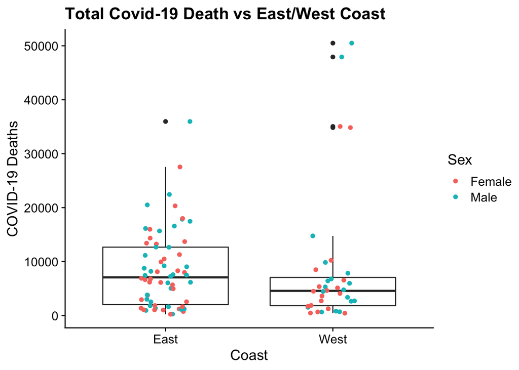

```r
CovidDataCoasts<-filter(Covid_19, Group=="By Total" & Sex!="All Sexes" & Age.Group=="All Ages" & State!="United States" & State!="Puerto Rico", State!= "New York City" )
Coast1<-ggplot(CovidDataCoasts) +
  aes(x=WC , y=COVID.19.Deaths) +
  geom_boxplot() +
  geom_jitter(width=.15, aes(color=Sex)) +
  ggtitle("Total Covid-19 Death vs East/West Coast") +
  labs(x="Coast", y="COVID-19 Deaths") +
  scale_x_discrete(labels = c('East', 'West')) +
  theme_cowplot() +
  theme(axis.text.x = element_text(angle = 0, vjust = 1, hjust=0.5))
plot(Coast1)
```

```r
table(Covid_19$State)
```

```
##
##        United States              Alabama               Alaska
##                 1530                 1530                 1530
##              Arizona             Arkansas           California
##                 1530                 1530                 1530
##             Colorado          Connecticut             Delaware
##                 1530                 1530                 1530
## District of Columbia              Florida              Georgia
##                 1530                 1530                 1530
##               Hawaii                Idaho             Illinois
##                 1530                 1530                 1530
##              Indiana                 Iowa               Kansas
##                 1530                 1530                 1530
##             Kentucky            Louisiana                Maine
##                 1530                 1530                 1530
##             Maryland        Massachusetts             Michigan
##                 1530                 1530                 1530
##            Minnesota          Mississippi             Missouri
##                 1530                 1530                 1530
##              Montana             Nebraska               Nevada
##                 1530                 1530                 1530
##        New Hampshire           New Jersey           New Mexico
##                 1530                 1530                 1530
##             New York        New York City       North Carolina
##                 1530                 1530                 1530
##         North Dakota                 Ohio             Oklahoma
##                 1530                 1530                 1530
##               Oregon         Pennsylvania         Rhode Island
##                 1530                 1530                 1530
##       South Carolina         South Dakota            Tennessee
##                 1530                 1530                 1530
##                Texas                 Utah              Vermont
##                 1530                 1530                 1530
##             Virginia           Washington        West Virginia
##                 1530                 1530                 1530
##            Wisconsin              Wyoming          Puerto Rico
##                 1530                 1530                 1530
```

Additionally, we can plot West coast vs East coast deaths by age range. Again, we will filter the age groups we wish to represent.

One additional line of code can be included. We can specify the labels of the legend and the color of the represented binary factor. This can be accomplished via the command:scale_colour_manual(labels=c(“Title”, “Title”), values= c(“color”, “color”))

Colors can be represented numerous ways in R. However, they can be conveniently picked by utilizing this provided resource from Columbia University.

http://www.stat.columbia.edu/~tzheng/files/Rcolor.pdf

This cheat sheet was created by Dr. Ying Wei.

```r
CovidDataCoasts1<-filter(Covid_19, Group=="By Total" & Age.Group!="All Ages" & Age.Group!="Under 1 year" & Age.Group!="1-4 years" & Age.Group!="5-14 years" & Age.Group!="15-24 years" & Age.Group!="25-34 years" & Age.Group!="35-44 years" & Age.Group!="45-54 years" & Age.Group!="55-64 years" & State!="United States" & State!="Puerto Rico", Sex!="Male" & Sex!="Female")
Coast2<-ggplot(CovidDataCoasts1, aes(x = Age.Group, y = COVID.19.Deaths)) +
  geom_point(aes(colour = factor(WC)),
             position = "jitter",
             alpha = 0.8,
             size=0.05) +
  geom_smooth(formula = y ~ x,method='lm',aes(group = factor(WC),
                              colour = factor(WC))) +
  theme(legend.position = "right") +
  ggtitle('Covid-19 Deaths by Age Group (Total) ') +
  labs(x= "Age Group", y= "COVID-19 Deaths", color="Legend") +
  scale_colour_manual(labels=c("East", "West"), values= c("darkblue", "red")) +
  theme(axis.text.x = element_text(angle = 90, vjust = 1, hjust=0.5))
  theme_cowplot()
```

[output not shown]

[output cut: 333 more lines]

[output not shown]

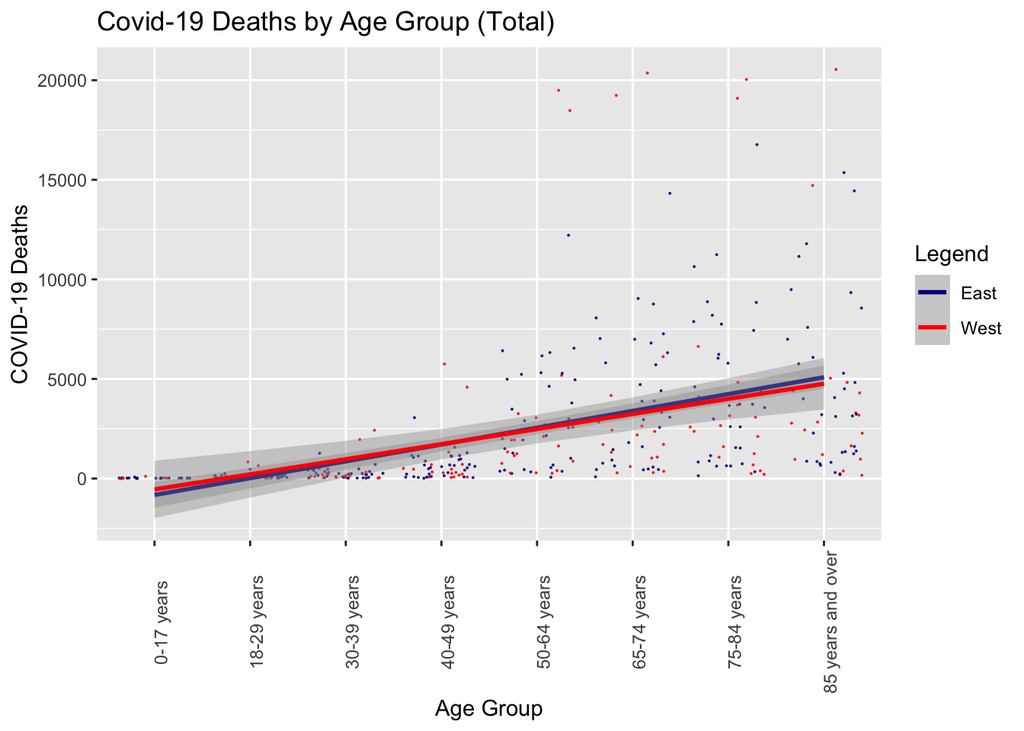

```r
plot(Coast2)
```

5. Plotting Data of COVID-19 Deaths from Pennsylvania (Total)

To really narrow analysis, we can further look at the number of COVID-19 deaths per year and month in Pennsylvania. The state of Pennsylvania was chosen for epidemiological relevance. Furthermore, refining the dataset to a single state is beneficial for improved data visualization.

```r
PennData<-filter(Covid_19, Sex!="All Sexes" & State=="Pennsylvania")
```

After running this new code chuck, note the new data frame “PennData” created from the “Covid_19” data frame.

This data frame can be further refined using the filter function to explore COVID-19 deaths by Age, Group, and Year similar to as what was previously completed in earlier sections. Note that the filtered “PennData” data frame is now being saved as “CovidDataPennTotal”, and that the number of observations in the data frame is decreasing as we continue to focus in on certain data.

The problem of adolescent observations having different age intervals that are not consistent with the way the adult age intervals collected is one again a problem here, however, the age groups that are included in the analysis are broken up differently. See if you can look at the filter code below before running the analysis, compare it to the code in part 2 of the “Visualizing the Data” section, and see how the filter code for age ranges differs.

```r
CovidDataPennTotal<-filter(PennData, Group=="By Total" & Age.Group!="All Ages" & Age.Group!="Under 1 year" & Age.Group!="1-4 years" & Age.Group!="5-14 years" & Age.Group!="15-24 years" & Age.Group!="25-34 years" & Age.Group!="35-44 years" & Age.Group!="45-54 years" & Age.Group!="55-64 years")
```

```r
PennTotal<-ggplot(CovidDataPennTotal, aes(x = Age.Group, y = COVID.19.Deaths)) +
  geom_point(aes(colour = factor(Sex)),
             position = "jitter",
             alpha = 0.8,     #Change transparency for aesthetics
             size=1.0) +      #Change size for aesthetics
  geom_smooth(formula = y ~ x,method='lm',aes(group = factor(Sex),
                              colour = factor(Sex))) +
  theme(legend.position = "right") +
  ggtitle('Covid-19 Deaths by Age in Pennsylvania (Total) ') +
  labs(x= "Age Group", y= "COVID-19 Deaths", color= "Gender") +
  theme(axis.text.x = element_text(angle = 90, vjust = 1, hjust=0.5))
  theme_cowplot()
```

[output not shown]

[output cut: 333 more lines]

[output not shown]

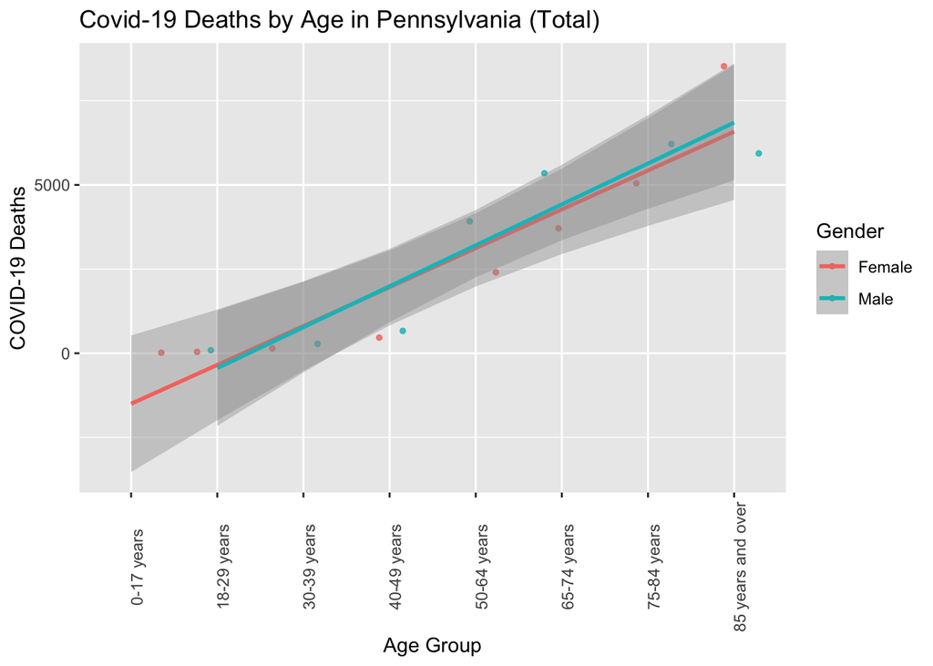

```r
plot(PennTotal)
```

A great, refined, visualization was created! Lets take the same code structure from the previous code chunk and look at COVID-19 Deaths from Pennsylvania by month. The creation of a new data frame, filtering, and creation of a new plot name should be applied. The next plot is a manipulation of the x axis (change to Month) and factor (change to Year). Of course, dress the plot up by changing plot titles.

One additional line of code, however, should be included to change the x axis numeric categories (which represent the numeric month) to a character (month name). This can be accomplished using the already loaded package “Stat2Data”. The command structure is as follows: scale_x_continuous(breaks = seq_along(month.name), labels = month.name). This line changes the month observation of “2” to display as February on the X axis.

(Line taken from https://stackoverflow.com/questions/69411847/changing-month-from-number-to-full-month-name-in-r)

```r
library(Stat2Data)
CovidDataPennMonth<-filter(PennData, Group=="By Month" & Age.Group=="All Ages")
PennMonth<-ggplot(CovidDataPennMonth, aes(x = Month, y = COVID.19.Deaths)) +
  geom_point(aes(colour = factor(Year)),
             position = "jitter",
             alpha = 0.8,
             size=0.05) +
  geom_smooth(formula = y ~ x,method='lm',aes(group = factor(Year),
                              colour = factor(Year))) +
  scale_x_continuous(breaks = seq_along(month.name), labels = month.name) +
  theme(legend.position = "right") +
  ggtitle('Covid-19 Deaths by Month in Pennsylvania ') +
  labs(x= "Month", y= "COVID-19 Deaths", color="Year") +
  theme(axis.text.x = element_text(angle = 90, vjust = 1, hjust=0.5))
  theme_cowplot()
```

[output not shown]

[output cut: 333 more lines]

[output not shown]

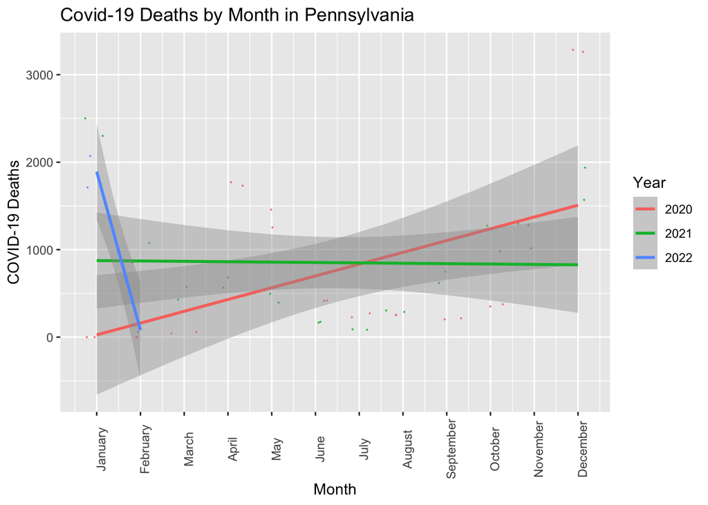

```r
plot(PennMonth)
```

This is a neat visual. Notice how the year 2022 only has two months of data collection. If statistical analysis were to be completed with this graph, the year 2022 would likely be removed as no informative comparison can be made using a variable that has incomplete data collection.

We can also take a look at monthly COVID-19 deaths between Female/Males in Pennsylvania. Again, the same formula of data visualization will be utilized, however, this time we will try using boxplots and density plots. Boxplots are a great graphing tool to apply to look for outlying data. Density plots are beneficial for looking at the representation of the distribution of a numeric variable.

Specify the geom_ of the plots by inserting geom_boxplot or geom_density into the code. Finally, theme_cowplot() allows users to plot the graphs in specified frames using the function: plot_grid(name, name, …, ncol=#).

```r
PM1<-ggplot(CovidDataPennMonth) +
  aes(x=Sex , y=COVID.19.Deaths) +
  geom_boxplot() +
  geom_jitter(width=.15, aes(color=Sex)) +
  ggtitle("Monthly Covid-19 Death vs Sex In Pennsylvania") +
  labs(x="Sex", y="COVID-19 Deaths") +
  theme_cowplot() +
  theme(axis.text.x = element_text(angle = 0, vjust = 1, hjust=0.5))

PM2<-ggplot(CovidDataPennMonth) +
  aes(x = COVID.19.Deaths, fill = Sex) +
  geom_density(alpha=.3) +
  labs(x= "Deaths", y="Density", title="Density vs Monthly Covid-19 Deaths In Pennsylvania")
  theme_cowplot()
```

[output not shown]

[output cut: 333 more lines]

[output not shown]

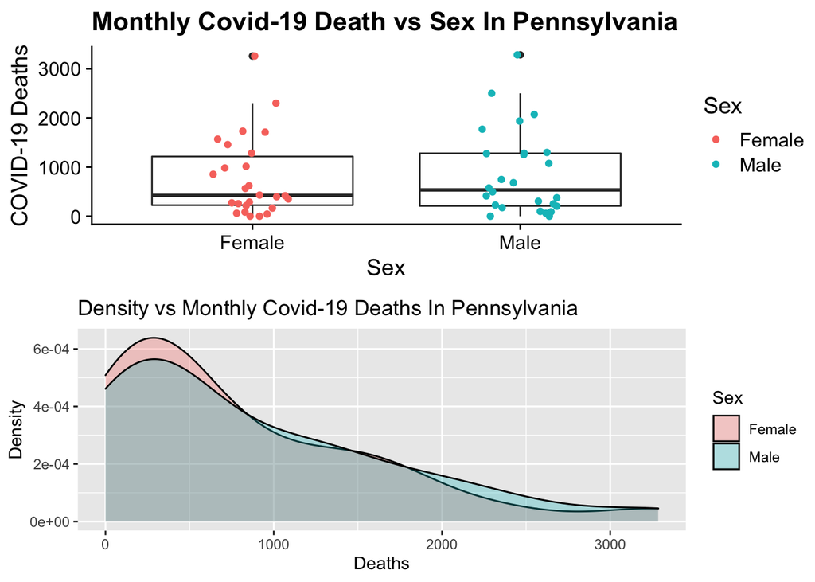

```r
plot_grid(PM1,PM2, ncol=1)
```

Finally, lets plot COVID-19 Deaths from Pennsylvania by year.

```r
CovidDataPennYear<-filter(PennData, Group=="By Year" & Age.Group=="All Ages")
PennYear<-ggplot(CovidDataPennYear, aes(x = Year, y = COVID.19.Deaths)) +
  geom_point(aes(colour = factor(Sex)),
             position = "jitter",
             alpha = 0.8,
             size=0.05) +
  geom_smooth(formula = y ~ x,method='lm',aes(group = factor(Sex),
                              colour = factor(Sex))) +
  theme(legend.position = "right") +
  ggtitle('Covid-19 Deaths by Month in Pennsylvania ') +
  labs(x= "Year", y= "COVID-19 Deaths", color="Gender") +
  theme(axis.text.x = element_text(angle = 90, vjust = 1, hjust=0.5))
  theme_cowplot()
```

[output not shown]

[output cut: 333 more lines]

[output not shown]

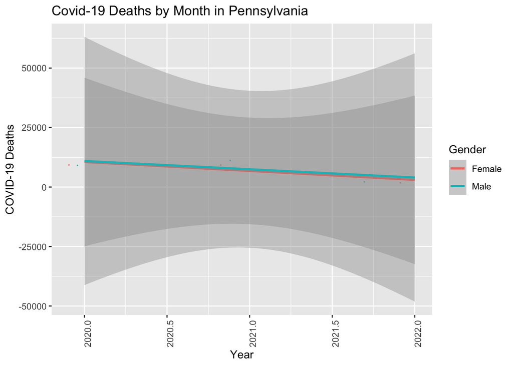

```r
plot(PennYear)
```

#STATISTICAL ANALYSIS:

As a reminder, the hypotheses we are interested in for this R tutorial are: 1. We hypothesize that there will be more COVID-19 deaths reported for the East coast. 2. We hypothesize that there will be more COVID-19 deaths reported for older individuals in all states across the US. 3. We hypothesize that there will be no difference in COVID-19 deaths between the to genders in the US.

In order to test these hypotheses, we will be creating linear models working solely with total deaths, or the “By Total” level of the “Group” column. This will allow is to avoid having to run a statistical analysis on a time series, which is something we are not covering in this tutorial.

1. We hypothesize that there will be more COVID-19 deaths reported for the East coast.

The first linear model we will be running will be used to determine if the total number of Covid-19 deaths on the East Coast is significantly different from those on the West Coast. The output of the linear model function will be used to explain the statistical analysis, but for now just follow along with the basic code format for a linear model:

lm(Response/Dependent Variable ~ Predictor/Independent Variable, data=data.frame)

Notice that the product of this function is assigned the identity “lmEvsW” for East vs. West Coast. This analysis is performed using the lmCovidDataCoasts dataset, with all sex, by total, All Age observations, excluding the “States” of “United States”, “New York City”, and “Peurto Rico”. The 51 observations are present within the data frame are explained by 1 per “state” for 51 “states” (the traditional 50 states + the District of Columbia). The summary(lmEvsW) plot(lmEvsW) functions should always be ran in tandem with the execution of a linear model in order to ensure the model can be assessed. Briefly look at the output below after running the code chunk, and then follow the text below the output describing the results of a linear model.

```r
lmCovidDataCoasts<-filter(Covid_19, Group=="By Total" & Sex=="All Sexes" & Age.Group=="All Ages" & State!="United States" & State!="Puerto Rico", State!= "New York City" )
lmEvsW <- lm(COVID.19.Deaths ~ WC, data=lmCovidDataCoasts)
summary(lmEvsW)
```

```
##
## Call:
## lm(formula = COVID.19.Deaths ~ WC, data = lmCovidDataCoasts)
##
## Residuals:
##    Min     1Q Median     3Q    Max
## -16349 -12674  -5230   5274  68391
##
## Coefficients:
##             Estimate Std. Error t value Pr(>|t|)
## (Intercept)  16850.2     3284.6   5.130 4.95e-06 ***
## WCTRUE         303.8     5528.9   0.055    0.956
## ---
## Signif. codes:  0 '***' 0.001 '**' 0.01 '*' 0.05 '.' 0.1 ' ' 1
##
## Residual standard error: 18870 on 49 degrees of freedom
## Multiple R-squared:  6.162e-05,  Adjusted R-squared:  -0.02035
## F-statistic: 0.00302 on 1 and 49 DF,  p-value: 0.9564
```

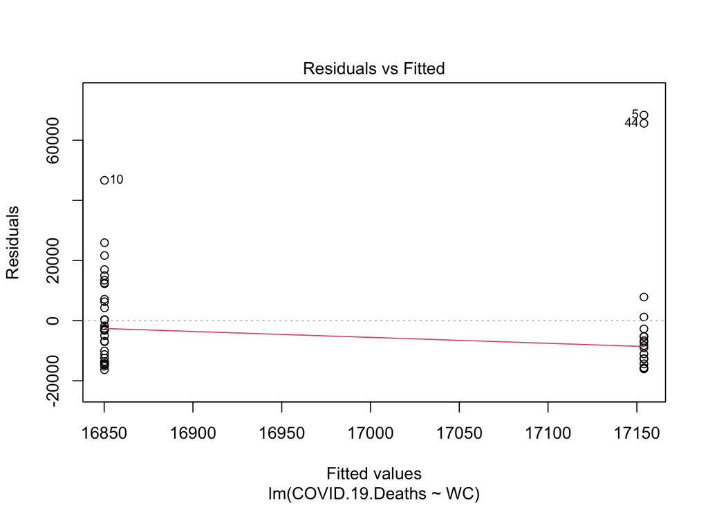

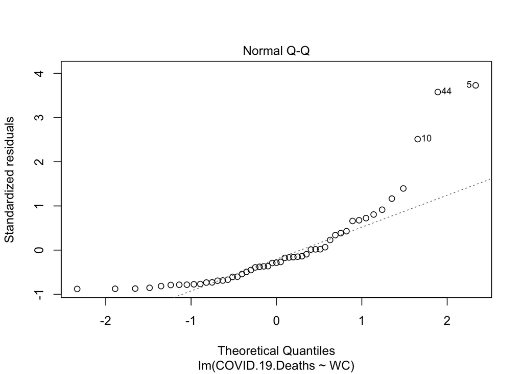

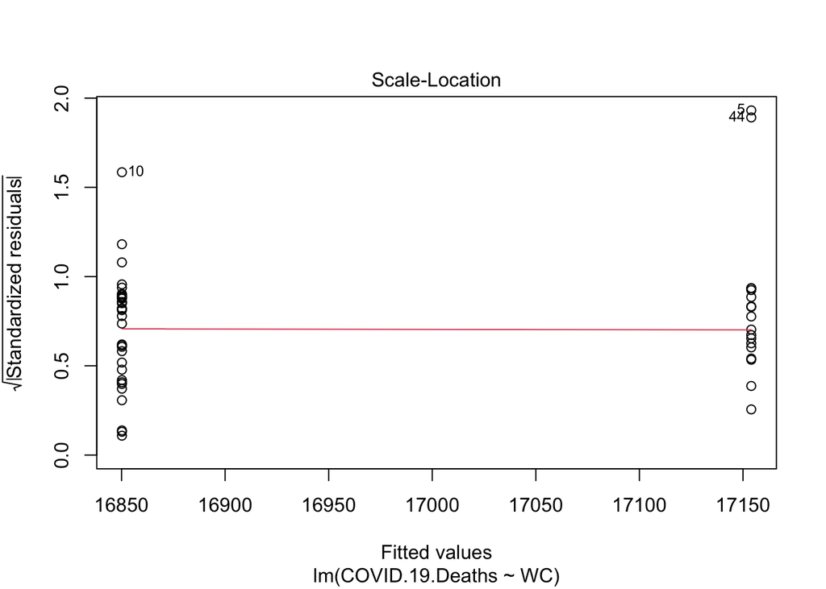

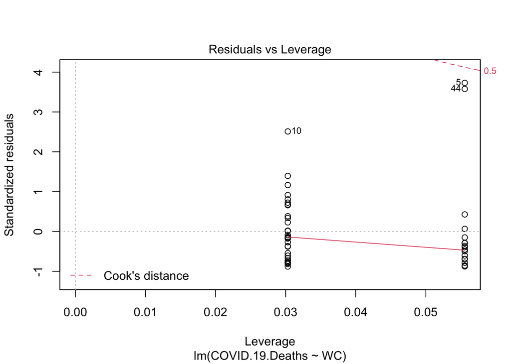

```r
plot(lmEvsW)
```

The assumptions required to perform a linear model include the following: i) Linearity: The relationship between X and the mean of Y is linear, or the X variable is categorical. In this case, we are comparing East Coast vs West Coast binomial categories, so we don’t have to check for linearity. In fact, we are only going to be analyzing categorical X variables for the remainder of this tutorial, so this constraint is not relevant to our analysis.

2. Homoscedasticity: The variance of the residuals is random for each X value. Select the second output frame above. Because we are looking at a categorical variable, our X values become these 2 categories (east and west coast). Notice that the distribution of residuals is fairly consistent across both X values.
3. Independence: Observations are independent of each other. We can determine from intuition that the number of Covid-19 deaths are not dependent on the State name. It is still possible that State may have an effect on Covid-19 deaths, but this is different than “state” being dependent on Covid-19 deaths.
4. Normality: For any fixed value of X, Y is normally distributed. Select the 3rd output frame. This can be evaluated from a qqplot, which you likely remember from your statistics course. If the points are distributed along the line, then the Y values are normally distributed for each X value.

Notice that we do not have normal distribution for this analysis. This does not make our linear model entirely not compatible with the data, but does require that we interpret the results with caution.

Interpreting Significance: Select the first output frame above. Theoretically what this linear model is doing is fitting a horizontal line through the weighted mean Y value for one category of X (call this X1). Then, the linear model is comparing the weighted mean Y value for X1 to the weighted mean Y value of category X2 and determining the probability (p value) that these two weighted mean values come from the same population. A linear model is capable of comparing a number of categorical variables like this, making it very useful.

Look under the “Coefficients” detection of output frame 1. “(Intercept)” shows the baseline X value that the rest are being compared to. RStudio automatically selects the baseline category for comparison by alphabetical order. Although it is not explicitly stated, this category above is “WCFALSE”, and WCTRUE is being compared to this baseline. The number under the “Estimate” column for “(Intercept)” represents the the weighted average number of deaths per East Coast (or WCFALSE) State, which in this case is 16850.2 deaths.

Now, looking at the WCTRUE row of code, notice the number under the “Estimate” column is 303.8 deaths. Remember, everything is in comparison to the baseline category (WCFALSE), so this is actually saying that states on the west coast have weighted average number of deaths per state that is higher by 303.8 deaths. However, by looking under the “Pr(>|t|)” (or p value) column in the WCTRUE row, we can see that this difference in weighted average is no where near close to being significant (p=0.956), and we can conclude that the number of Covid-19 deaths do not differ significantly by coast.

2. We hypothesize that there will be more COVID-19 deaths reported for older individuals in all states across the US.

```r
Covid_19%>%
  filter (State != "United States" & State != "District of Columbia" & State != "New York City" & State != "Puerto Rico") %>%
  filter(Group == "By Total") %>%
  filter(Sex == "All Sexes") %>%
  filter((Age.Group != "0-17 years" & Age.Group != "All Ages" & Age.Group != "50-64 years" & Age.Group != "Under 1 year" & Age.Group != "1-4 years" & Age.Group != "5-14 years" & Age.Group != "18-29 years" & Age.Group != "30-39 years" & Age.Group != "40-49 years" & Age.Group != "15-24 years"))->Covid_19.State.Deaths.Age

lmOvsY <- lm(COVID.19.Deaths ~ Age.Group, data=Covid_19.State.Deaths.Age)
summary(lmOvsY)
```

```
##
## Call:
## lm(formula = COVID.19.Deaths ~ Age.Group, data = Covid_19.State.Deaths.Age)
##
## Residuals:
##     Min      1Q  Median      3Q     Max
## -4297.8 -1460.7  -258.3   230.6 16421.2
##
## Coefficients:
##                            Estimate Std. Error t value Pr(>|t|)
## (Intercept)                   193.1      456.5   0.423 0.672610
## Age.Group35-44 years          291.8      645.6   0.452 0.651603
## Age.Group45-54 years          972.7      645.6   1.507 0.132826
## Age.Group55-64 years         2340.0      645.6   3.624 0.000334 ***
## Age.Group65-74 years         3745.8      645.6   5.802 1.49e-08 ***
## Age.Group75-84 years         4240.7      645.6   6.568 1.89e-10 ***
## Age.Group85 years and over   4264.2      645.6   6.605 1.52e-10 ***
## ---
## Signif. codes:  0 '***' 0.001 '**' 0.01 '*' 0.05 '.' 0.1 ' ' 1
##
## Residual standard error: 3228 on 343 degrees of freedom
## Multiple R-squared:  0.2253, Adjusted R-squared:  0.2118
## F-statistic: 16.63 on 6 and 343 DF,  p-value: < 2.2e-16
```

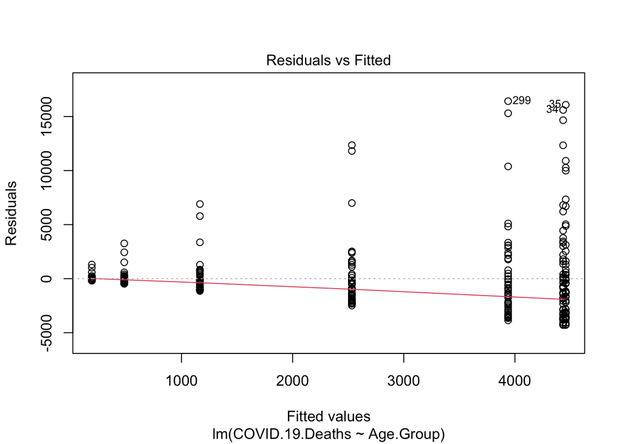

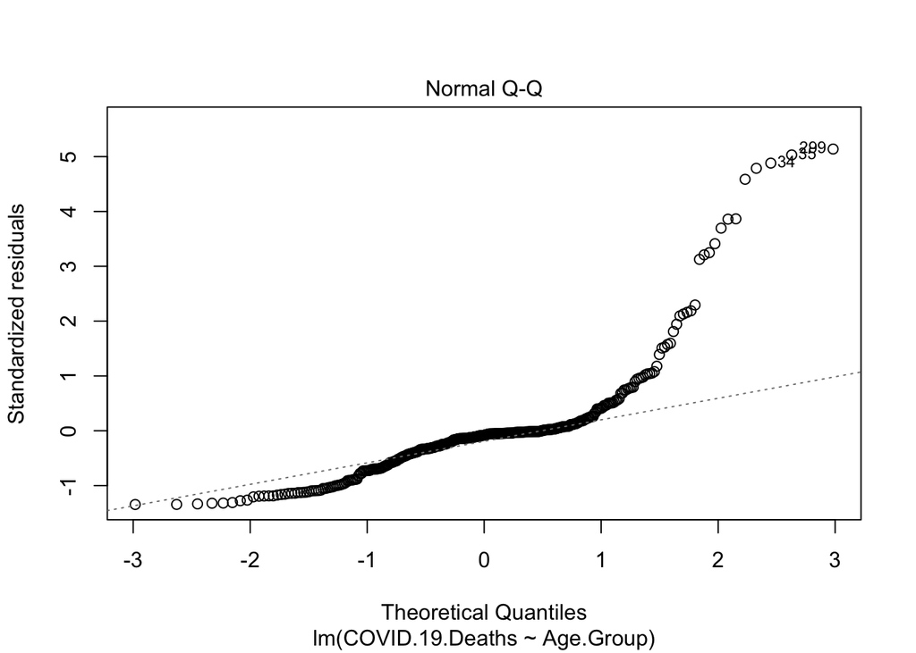

```
## hat values (leverages) are all = 0.02
##  and there are no factor predictors; no plot no. 5
```

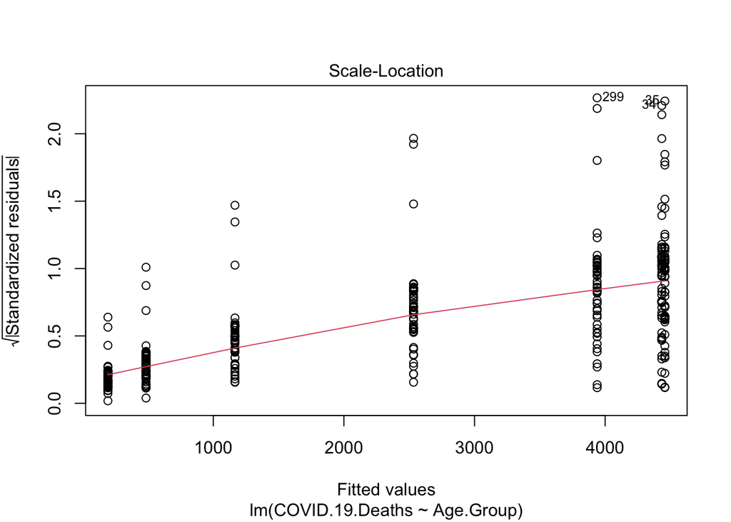

```r
plot(lmOvsY)
```

3. We hypothesize that there will be no difference in COVID-19 deaths between the to genders in the US

Run the code directly below this text:

```r
Covid_19%>%
  filter (State != "United States" & State != "District of Columbia" & State != "New York City" & State != "Puerto Rico") %>%
  filter(Group == "By Total") %>%
  filter(Sex != "All Sexes") %>%
  filter((Age.Group == "All Ages"))->Covid_19.State.Deaths.Sex
```

This code has created a data frame titled “Covid_19.State.Deaths.Sex”, containing cumulative data on the total number of deaths since the beginning of the pandemic. In addition, these deaths are further broken down by state and sex (male and female are separate). Study the data frame, and then attempt to run a linear model below investigating if the number of Covid-19 deaths in the US is dependent on Sex. Use the following functions:

lm.name<-lm(response.variable ~ predictor.variable, data=data.set.name) summary(lm.name) plot(lm.name)

For the correct code, see after the acknowledgement section below.

```r
#type here
```

Follow up questions to consider: - What assumptions were violated? - Was there a significant difference between the death of male and females? - Make a conclusion about our hypothesis #3 from this output

## Target Audience

Upper level epidemiology class using R Studio for the first time.

## Grading

Each student will be expected to complete the following tasks to earn 85% of the points available for this assignment (21/25).

- Identify and obtain suitable dataset
- Use a Github repository and version control to collaborate on the project
- Spend 4-6 hours preparing, coding, and testing tutorial
  - Data exploration
  - Data visualization
  - Hypothesis testing
- Present tutorial in class
- Provide public archive suitable for sharing to students/faculty

Tutorials from previous classes can be viewed at our public github site: https://github.com/Bucknell-Biol364

Additional credit will be awarded for providing assistance to other groups and for the development of a tutorial that goes beyond the minimal expectations listed above.

# Acknowledgements

Outline: README(Maisy) 1) Introduction to class (Ashley) 2) Introduction to R (Maisy) Define RMD vs Regular R Loading Data Set Load Packages Refer to glossary for a function/stats overview… 3) Explore Data Set (with function explanations) (Ashley) Formulate a question Read data Check packaging Run structure Look at top and bottom of data Check your n’s 4) Visualize Data Set 1. Timeline vs death (Maisy) 2. Rank net deaths by state (Ben) 3. Do older people have higher death rates than younger (Ben) 4. West coast vs east coast (Ashley) 5. Covid-19 Deaths in Pennsylvania (Ashley) 5) Statistical analysis to answer hypothesis (Ben) 1. We hypothesize that there will be more COVID-19 deaths reported for the East coast. 2. We hypothesize that there will be more COVID-19 deaths reported for older individuals in all states across the US. 3. We hypothesize that there will be no difference in COVID-19 deaths between the to genders in the US.

Solution code to final linear model:

```r
lmCDM1 <- lm(COVID.19.Deaths ~ Sex, data=Covid_19.State.Deaths.Sex)
summary(lmCDM1)
```

```
##
## Call:
## lm(formula = COVID.19.Deaths ~ Sex, data = Covid_19.State.Deaths.Sex)
##
## Residuals:
##    Min     1Q Median     3Q    Max
##  -9268  -6208  -2484   2572  40962
##
## Coefficients:
##             Estimate Std. Error t value Pr(>|t|)
## (Intercept)     7728       1341   5.762 9.62e-08 ***
## SexMale         1806       1897   0.952    0.343
## ---
## Signif. codes:  0 '***' 0.001 '**' 0.01 '*' 0.05 '.' 0.1 ' ' 1
##
## Residual standard error: 9484 on 98 degrees of freedom
## Multiple R-squared:  0.009164,   Adjusted R-squared:  -0.0009462
## F-statistic: 0.9064 on 1 and 98 DF,  p-value: 0.3434
```

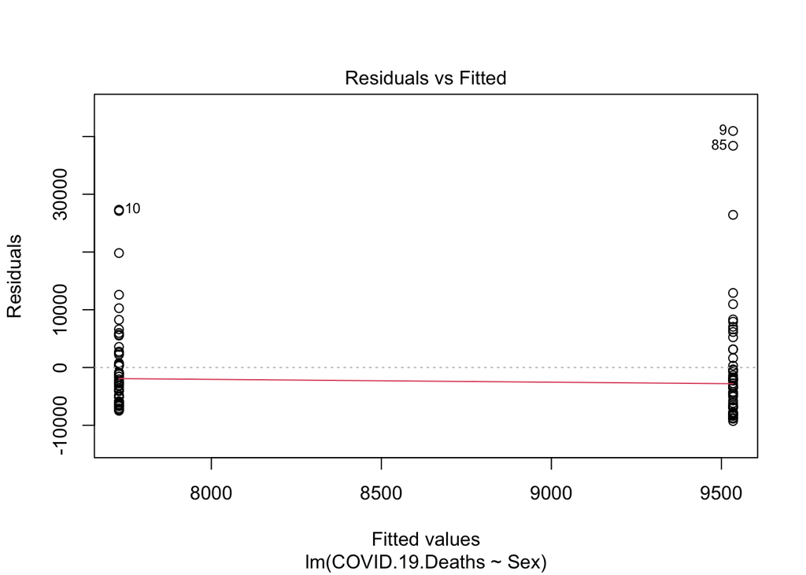

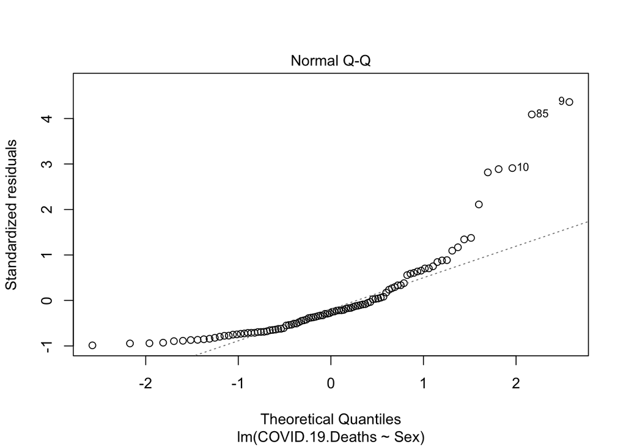

```
## hat values (leverages) are all = 0.02
##  and there are no factor predictors; no plot no. 5
```

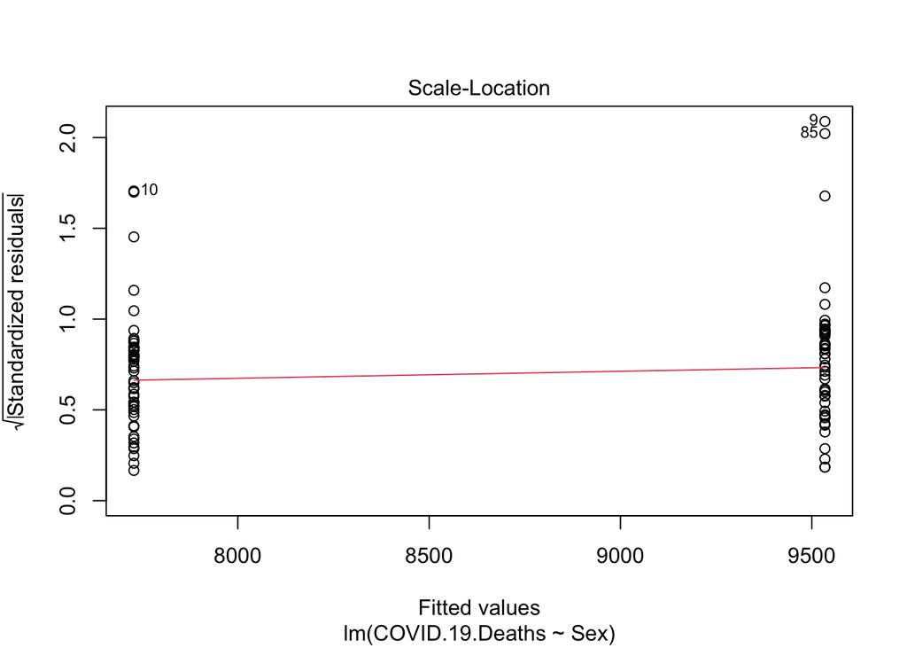

```r
plot(lmCDM1)
```